# KakaoTalk_Chating_Wordcloud

PYB

2021 1 3

## **학과 단체 대화방의 단어를 워드 클라우드 시각화 구현**

R을 공부하고나서 첫 개인 프로젝트로 워드 클라우드를 구현해보았다. R을 처음 접할 때 워드 클라우드 기법이 가장 먼저 눈에 들어왔고 꼭 한 번 해보고 싶은 작업이었기 때문이다. 문자 데이터는 나와 직접적으로 관련이 있는 학과 단체 대화방의 데이터를 이용했다.

**[프로젝트 목적]**  
1. 채팅방에 자주 등장하는 단어들을 시각화 하여 대화의 흐름, 분위기를 역으로 파악하기  
2. 첫 개인 프로젝트로 평소 관심이 있었던 시각화 기능 구현하기  
3. 모방학습 및 본인의 R 프로그램 실력 파악하기

#### 1.준비 작업

작업에 필요한 패키지를 설치하고 로드한다. install.packages() 함수로 필요한 패키지를 설치한다.

```r
# 패키지 설치
install.packages("KoNLP")
install.packages("wordcloud2")
install.packages("ggplot2")
install.packages("dplyr")
install.packages("RColorBrewer")
```

```r
# 패키지 로드
library(KoNLP) # 자연어 처리 패키지
library(wordcloud2) # 워드 클라우드2 패키지
library(ggplot2) # 시각화 패키지
library(dplyr) # 전처리 패키지
library(RColorBrewer) # 글자색 표현 패키지
useNIADic() # 사전 로드
```

```
## Backup was just finished!
## 1213109 words dictionary was built.
```

#### 2.사전에 없을 법한 단어를 직접 사전에 넣기

사전은 useNIADic()를 이용했다. 비록 useNIADiC에 많은 단어들이 있지만, 우리가 실생활에서 쓰는 은어, 줄임말 등은 존재하지 않는다.  
때문에 mergeUserDic 함수를 이용하여 사전에 없을 법한 단어를 직접 추가했다.  
코드 한 줄, 한 줄을 실행하는데 많은 시간이 걸렸다.

```r
mergeUserDic(data.frame(c("G-CA"), c("ncn")))
```

```
## 1 words were added to dic_user.txt.
```

```r
mergeUserDic(data.frame(c("코로나19"), c("ncn")))
```

```
## 1 words were added to dic_user.txt.
```

```r
mergeUserDic(data.frame(c("유증상자"), c("ncn")))
```

```
## 1 words were added to dic_user.txt.
```

```r
mergeUserDic(data.frame(c("자택격리자"), c("ncn")))
```

```
## 1 words were added to dic_user.txt.
```

```r
mergeUserDic(data.frame(c("FAM"), c("ncn")))
```

```
## 1 words were added to dic_user.txt.
```

```r
mergeUserDic(data.frame(c("비모수"), c("ncn")))
```

```
## 1 words were added to dic_user.txt.
```

```r
mergeUserDic(data.frame(c("팸인원"), c("ncn")))
```

```
## 1 words were added to dic_user.txt.
```

```r
mergeUserDic(data.frame(c("업로드"), c("ncn")))
```

```
## 1 words were added to dic_user.txt.
```

```r
mergeUserDic(data.frame(c("slc"), c("ncn")))
```

```
## 1 words were added to dic_user.txt.
```

```r
mergeUserDic(data.frame(c("조교쌤"), c("ncn")))
```

```
## 1 words were added to dic_user.txt.
```

```r
mergeUserDic(data.frame(c("e참뜰"), c("ncn")))
```

```
## 1 words were added to dic_user.txt.
```

```r
mergeUserDic(data.frame(c("해인자"), c("ncn")))
```

```
## 1 words were added to dic_user.txt.
```

```r
mergeUserDic(data.frame(c("토익"), c("ncn")))
```

```
## 1 words were added to dic_user.txt.
```

```r
mergeUserDic(data.frame(c("컴활"), c("ncn")))
```

```
## 1 words were added to dic_user.txt.
```

```r
mergeUserDic(data.frame(c("e스포츠"), c("ncn")))
```

```
## 1 words were added to dic_user.txt.
```

```r
mergeUserDic(data.frame(c("라온"), c("ncn")))
```

```
## 1 words were added to dic_user.txt.
```

```r
mergeUserDic(data.frame(c("늘봄"), c("ncn")))
```

```
## 1 words were added to dic_user.txt.
```

```r
mergeUserDic(data.frame(c("카톡"), c("ncn")))
```

```
## 1 words were added to dic_user.txt.
```

```r
mergeUserDic(data.frame(c("생협쿠폰"), c("ncn")))
```

```
## 1 words were added to dic_user.txt.
```

```r
mergeUserDic(data.frame(c("확산"), c("ncn")))
```

```
## 1 words were added to dic_user.txt.
```

```r
mergeUserDic(data.frame(c("코로나"), c("ncn")))
```

```
## 1 words were added to dic_user.txt.
```

```r
mergeUserDic(data.frame(c("통개학개론"), c("ncn")))
```

```
## 1 words were added to dic_user.txt.
```

```r
mergeUserDic(data.frame(c("분포론"), c("ncn")))
```

```
## 1 words were added to dic_user.txt.
```

```r
mergeUserDic(data.frame(c("학업코칭"), c("ncn")))
```

```
## 1 words were added to dic_user.txt.
```

```r
mergeUserDic(data.frame(c("갠톡"), c("ncn")))
```

```
## 1 words were added to dic_user.txt.
```

```r
mergeUserDic(data.frame(c("동행"), c("ncn")))
```

```
## 1 words were added to dic_user.txt.
```

```r
mergeUserDic(data.frame(c("멘토"), c("ncn")))
```

```
## 1 words were added to dic_user.txt.
```

```r
mergeUserDic(data.frame(c("계절학기"), c("ncn")))
```

```
## 1 words were added to dic_user.txt.
```

```r
mergeUserDic(data.frame(c("과대"), c("ncn")))
```

```
## 1 words were added to dic_user.txt.
```

```r
mergeUserDic(data.frame(c("부과대"), c("ncn")))
```

```
## 1 words were added to dic_user.txt.
```

```r
mergeUserDic(data.frame(c("특별학점"), c("ncn")))
```

```
## 1 words were added to dic_user.txt.
```

```r
mergeUserDic(data.frame(c("실험계획법"), c("ncn")))
```

```
## 1 words were added to dic_user.txt.
```

```r
mergeUserDic(data.frame(c("페이스북"), c("ncn")))
```

```
## 1 words were added to dic_user.txt.
```

```r
mergeUserDic(data.frame(c("학우"), c("ncn")))
```

```
## 1 words were added to dic_user.txt.
```

```r
mergeUserDic(data.frame(c("수강신청"), c("ncn")))
```

```
## 1 words were added to dic_user.txt.
```

```r
mergeUserDic(data.frame(c("장바구니제"), c("ncn")))
```

```
## 1 words were added to dic_user.txt.
```

```r
mergeUserDic(data.frame(c("총학생회"), c("ncn")))
```

```
## 1 words were added to dic_user.txt.
```

```r
mergeUserDic(data.frame(c("동행"), c("ncn")))
```

```
## 1 words were added to dic_user.txt.
```

```r
mergeUserDic(data.frame(c("라온"), c("ncn")))
```

```
## 1 words were added to dic_user.txt.
```

```r
mergeUserDic(data.frame(c("단기어학연수"), c("ncn")))
```

```
## 1 words were added to dic_user.txt.
```

```r
mergeUserDic(data.frame(c("동계계절학기"), c("ncn")))
```

```
## 1 words were added to dic_user.txt.
```

```r
mergeUserDic(data.frame(c("동계"), c("ncn")))
```

```
## 1 words were added to dic_user.txt.
```

```r
mergeUserDic(data.frame(c("하계"), c("ncn")))
```

```
## 1 words were added to dic_user.txt.
```

```r
mergeUserDic(data.frame(c("하계계절학기"), c("ncn")))
```

```
## 1 words were added to dic_user.txt.
```

```r
mergeUserDic(data.frame(c("계절학기"), c("ncn")))
```

```
## 1 words were added to dic_user.txt.
```

```r
mergeUserDic(data.frame(c("학과 특성화 장학금"), c("ncn")))
```

```
## 1 words were added to dic_user.txt.
```

```r
mergeUserDic(data.frame(c("선형대수학"), c("ncn")))
```

```
## 1 words were added to dic_user.txt.
```

```r
mergeUserDic(data.frame(c("강릉원주대학교"), c("ncn")))
```

```
## 1 words were added to dic_user.txt.
```

```r
mergeUserDic(data.frame(c("국립강릉원주대학교"), c("ncn")))
```

```
## 1 words were added to dic_user.txt.
```

```r
mergeUserDic(data.frame(c("복수전공"), c("ncn")))
```

```
## 1 words were added to dic_user.txt.
```

```r
mergeUserDic(data.frame(c("복학"), c("ncn")))
```

```
## 1 words were added to dic_user.txt.
```

```r
mergeUserDic(data.frame(c("휴학"), c("ncn")))
```

```
## 1 words were added to dic_user.txt.
```

```r
mergeUserDic(data.frame(c("학습법"), c("ncn")))
```

```
## 1 words were added to dic_user.txt.
```

```r
mergeUserDic(data.frame(c("3학년"), c("ncn")))
```

```
## 1 words were added to dic_user.txt.
```

```r
mergeUserDic(data.frame(c("4학년"), c("ncn")))
```

```
## 1 words were added to dic_user.txt.
```

```r
mergeUserDic(data.frame(c("여름계절학기"), c("ncn")))
```

```
## 1 words were added to dic_user.txt.
```

```r
mergeUserDic(data.frame(c("품질관리"), c("ncn")))
```

```
## 1 words were added to dic_user.txt.
```

```r
mergeUserDic(data.frame(c("등록금"), c("ncn")))
```

```
## 1 words were added to dic_user.txt.
```

```r
mergeUserDic(data.frame(c("추가"), c("ncn")))
```

```
## 1 words were added to dic_user.txt.
```

```r
mergeUserDic(data.frame(c("납부"), c("ncn")))
```

```
## 1 words were added to dic_user.txt.
```

```r
mergeUserDic(data.frame(c("멘토링"), c("ncn")))
```

```
## 1 words were added to dic_user.txt.
```

```r
mergeUserDic(data.frame(c("정보통계학과"), c("ncn")))
```

```
## 1 words were added to dic_user.txt.
```

```r
mergeUserDic(data.frame(c("학회장"), c("ncn")))
```

```
## 1 words were added to dic_user.txt.
```

```r
mergeUserDic(data.frame(c("톡게시판"), c("ncn")))
```

```
## 1 words were added to dic_user.txt.
```

```r
mergeUserDic(data.frame(c("롤"), c("ncn")))
```

```
## 1 words were added to dic_user.txt.
```

```r
mergeUserDic(data.frame(c("201호"), c("ncn")))
```

```
## 1 words were added to dic_user.txt.
```

```r
mergeUserDic(data.frame(c("연습문제"), c("ncn")))
```

```
## 1 words were added to dic_user.txt.
```

```r
mergeUserDic(data.frame(c("기말고사"), c("ncn")))
```

```
## 1 words were added to dic_user.txt.
```

```r
mergeUserDic(data.frame(c("중간고사"), c("ncn")))
```

```
## 1 words were added to dic_user.txt.
```

```r
mergeUserDic(data.frame(c("단일후보"), c("ncn")))
```

```
## 1 words were added to dic_user.txt.
```

```r
mergeUserDic(data.frame(c("차기학회장"), c("ncn")))
```

```
## 1 words were added to dic_user.txt.
```

```r
mergeUserDic(data.frame(c("파일"), c("ncn")))
```

```
## 1 words were added to dic_user.txt.
```

```r
mergeUserDic(data.frame(c("근로 장학금"), c("ncn")))
```

```
## 1 words were added to dic_user.txt.
```

```r
mergeUserDic(data.frame(c("국가장학금"), c("ncn")))
```

```
## 1 words were added to dic_user.txt.
```

```r
mergeUserDic(data.frame(c("자연대"), c("ncn")))
```

```
## 1 words were added to dic_user.txt.
```

```r
mergeUserDic(data.frame(c("실험계획"), c("ncn")))
```

```
## 1 words were added to dic_user.txt.
```

```r
mergeUserDic(data.frame(c("특별학점"), c("ncn")))
```

```
## 1 words were added to dic_user.txt.
```

```r
mergeUserDic(data.frame(c("2학기"), c("ncn")))
```

```
## 1 words were added to dic_user.txt.
```

```r
mergeUserDic(data.frame(c("배움모둠"), c("ncn")))
```

```
## 1 words were added to dic_user.txt.
```

```r
mergeUserDic(data.frame(c("차기학회장"), c("ncn")))
```

```
## 1 words were added to dic_user.txt.
```

```r
mergeUserDic(data.frame(c("강릉"), c("ncn")))
```

```
## 1 words were added to dic_user.txt.
```

```r
mergeUserDic(data.frame(c("승인절차"), c("ncn")))
```

```
## 1 words were added to dic_user.txt.
```

```r
mergeUserDic(data.frame(c("이수증"), c("ncn")))
```

```
## 1 words were added to dic_user.txt.
```

```r
mergeUserDic(data.frame(c("안전교육"), c("ncn")))
```

```
## 1 words were added to dic_user.txt.
```

```r
mergeUserDic(data.frame(c("입학본부"), c("ncn")))
```

```
## 1 words were added to dic_user.txt.
```

```r
mergeUserDic(data.frame(c("공약설명회"), c("ncn")))
```

```
## 1 words were added to dic_user.txt.
```

```r
mergeUserDic(data.frame(c("질의응답"), c("ncn")))
```

```
## 1 words were added to dic_user.txt.
```

```r
mergeUserDic(data.frame(c("영상재생"), c("ncn")))
```

```
## 1 words were added to dic_user.txt.
```

```r
mergeUserDic(data.frame(c("오류"), c("ncn")))
```

```
## 1 words were added to dic_user.txt.
```

#### 3.text2 불러오기

readLine() 함수를 이용해서 문자 데이터를 한 줄씩 불러온다.

```r
text1 <- readLines("text2.txt")
head(text1, 10) # 상위 10개 추출
```

```
##  [1] " (확진, 의사, 조사대상 유증상자, 자택격리자 등) 해당사항 있으신 분 따로 연락 해주세요"
##  [2] " 응용통계 듣는 사람들 중에 강릉 아닌 사람 조교 쌤한테 주소 찍어서 보내주면  책 보내 주신다고 합니다."
##  [3] " 팸인원 짜고 있는데 조장 부조장하고싶은사람 조교 쌤한테 갠톡 보내주세요"
##  [4] " FAM 관련해서 조장부조장 및 인원들 월요일 날 전해드릴 예정이고 3,4학년 중에 조장 부조장 더 하고 싶은 사람 있으면 조교쌤 한테 카톡 남겨 놓으시면 됩니다."
##  [5] " 인원이 많을 경우 사다리타기로 정한다고 합니다."
##  [6] " 교수님 과목 공지사항 업데이트 됐으니 듣는 분들은 확인 하세요 (통계학개론 응용통계 분포론)"
##  [7] " 비모수 생존분석 통계분석 (강준성교수님)과목 과제물 제출할 때 사진으로 올리지 말고 스캔해서 pdf로 올리라고 하십니다."
##  [8] " 안녕하세요. 총학생회 ‘동행’입니다!!"
##  [9] " 분포론 강의 올라 왔습니다."
## [10] " 학과 특성화 장학금 신청할 사람은 계획서 갠톡으로 조교쌤한테 목요일까지 주면 됩니다."
```

#### 4.명사 추출

extractNoun()함수로 한 문장 내에서 명사를 분리해서 리스트 형태로 반환한다.  
[[ ]] 가 list 형태로 되어 있다는 것을 의미한다.

```r
text2 <- extractNoun(text1)
head(text2, 10) # 상위 10개 추출
```

```
## [[1]]
##  [1] "확진"       "의사"       "조사대상"   "유증상자"   "자택격리자"
##  [6] "등"         "해당"       "사항"       "분"         "연락"
##
## [[2]]
## [1] "응용"   "통계"   "사람들" "중"     "강릉"   "사람"   "조교"   "쌤"
## [9] "책"
##
## [[3]]
##  [1] "팸인원" "조장"   "부조"   "장하"   "고싶"   "은사"   "람"     "조교"
##  [9] "쌤"     "갠톡"
##
## [[4]]
##  [1] "FAM"    "관련"   "해서"   "조장"   "부조"   "장"     "인원"   "들"
##  [9] "월요일" "날"     "예정"   "3"      "4학년"  "중"     "조장"   "조장"
## [17] "사람"   "조교쌤" "한"     "테"     "카톡"
##
## [[5]]
## [1] "인원"       "경우"       "사다리타기"
##
## [[6]]
##  [1] "교수님"   "과목"     "공지사항" "업데이트" "분"       "확인"
##  [7] "통계학"   "개론"     "응용"     "통계"     "분포론"
##
## [[7]]
##  [1] "비모수"   "생존"     "분석"     "통계분석" "준성"     "교수님"
##  [7] "과목"     "과제물"   "제출"     "할"       "때"       "사진"
## [13] "스캔"     "해서"     "pdf"
##
## [[8]]
## [1] "안녕"            "하"              "총학생회"        "‘동행’입니다!"
##
## [[9]]
## [1] "분포론" "강의"
##
## [[10]]
##  [1] "학과"   "특성화" "장학금" "신청"   "할"     "사람"   "계획"   "갠톡"
##  [9] "조교쌤" "목요일"
```

#### 5.리스트 형태 데이터를 순수 벡터 형태로 변환

```r
data_list  <- unlist(text2)
head(data_list, 50) # 상위 50개 추출
```

```
##  [1] "확진"       "의사"       "조사대상"   "유증상자"   "자택격리자"
##  [6] "등"         "해당"       "사항"       "분"         "연락"
## [11] "응용"       "통계"       "사람들"     "중"         "강릉"
## [16] "사람"       "조교"       "쌤"         "책"         "팸인원"
## [21] "조장"       "부조"       "장하"       "고싶"       "은사"
## [26] "람"         "조교"       "쌤"         "갠톡"       "FAM"
## [31] "관련"       "해서"       "조장"       "부조"       "장"
## [36] "인원"       "들"         "월요일"     "날"         "예정"
## [41] "3"          "4학년"      "중"         "조장"       "조장"
## [46] "사람"       "조교쌤"     "한"         "테"         "카톡"
```

#### 6.불용어 처리

여기서는 시각화에 구현할 필요가 없는 문자들을 제거하거나 다른 단어로 치환하는 과정을 거친다.매우 중요한 순서이며 이 과정을 잘 거처야 의미 있는 문자들만 추출할 수 있다. 정규표현식을 이용하면 빠른 전처리가 가능하다.  
그리고 한 글자 데이터는 의미 없는 문자라고 판단해서 최소 두 글자 이상인 문자들만 추려서 진행하는 것도 좋은 방법이다.  
불용어 처리를 하면서 table() 함수로 단어의 빈도를 확인하는 방법도 편리하다. 전처리하면서 문자 처리 상황을 알 수 있기 때문에 어떤 단어를 더 제거하거나 치환해야 하는지 파악할 수 있기 때문이다.

```r
data_list <- gsub("\\d+", "", data_list) # 숫자 제거
data_list <- gsub("\\(", "", data_list) # ( 괄호 제거
data_list <- gsub("\\)", "", data_list) # ) 괄호 제거
data_list <- gsub("[A-Za-z]", "", data_list) # 영문자 제거
data_list <- gsub("[\\(]~!@#$%&*()_+=?", '', data_list) # 특수문자 제거
data_list <- gsub('[ㄱ-ㅎ]', '', data_list) # 자음제거
data_list <- gsub('(ㅜ|ㅠ)', '', data_list) # ㅜㅜ or ㅠㅠ 제거
data_list <- gsub("[0-9]", '', data_list)
data_list <- gsub("주기", "", data_list)
data_list <- gsub("차기", "", data_list)
data_list <- gsub("관련", "", data_list)
data_list <- gsub("참뜰", "e참뜰", data_list)
data_list <- gsub("과제\\s*", "과제", data_list) # '과제'로 시작하는 단어는 무엇이든지 '과제'로 변환
data_list <- gsub("갠톡\\s*", "갠톡", data_list)
data_list <- gsub("자연\\s*", "", data_list)
data_list <- gsub("자대\\s*", "", data_list)
data_list <- gsub("자연\\s*", "", data_list)
data_list <- gsub("조교쌤", "조교", data_list)
data_list <- gsub("고싶", "", data_list)
data_list <- gsub("거점", "", data_list)
data_list <- gsub("계절학", "", data_list)
data_list <- gsub("그전", "", data_list)
data_list <- gsub("감시", "", data_list)
data_list <- gsub('(기말|기말고사)', "기말고사", data_list)
data_list <- gsub("국가장", "", data_list)
data_list <- gsub("꼭해주세", "", data_list)
data_list <- gsub("내년", "", data_list)
data_list <- gsub("다다", "", data_list)
data_list <- gsub("들입", "", data_list)
data_list <- gsub("만나뵙", "", data_list)
data_list <- gsub("다급", "", data_list)
data_list <- gsub("기본적", "", data_list)
data_list <- gsub("동연", "", data_list)
data_list <- gsub("다시", "", data_list)
data_list <- gsub("동영상올릴", "", data_list)
data_list <- gsub("단일후보", "", data_list)
data_list <- gsub("목요", "", data_list)
data_list <- gsub("부조", "", data_list)
data_list <- gsub("부과", "", data_list)
data_list <- gsub("본부", "", data_list)
data_list <- gsub("보행로", "", data_list)
data_list <- gsub("아무", "", data_list)
data_list <- gsub("안녕", "", data_list)
data_list <- gsub("안녕하십니까", "", data_list)
data_list <- gsub("사다리타기", "", data_list)
data_list <- gsub("오후9시까지는", "", data_list)
data_list <- gsub("오전8시30분부터", "", data_list)
data_list <- gsub("이거", "", data_list)
data_list <- gsub("있습니", "", data_list)
data_list <- gsub("이번", "", data_list)
data_list <- gsub("유증", "", data_list)
data_list <- gsub("약간", "", data_list)
data_list <- gsub("오후", "", data_list)
data_list <- gsub("^특별학점\\W토익", "", data_list)
data_list <- gsub("^수정\\W중간", "", data_list)
data_list <- gsub("저번", "", data_list)
data_list <- gsub("준성", "", data_list)
data_list <- gsub("중이", "", data_list)
data_list <- gsub("제35대", "", data_list)
data_list <- gsub("하게", "", data_list)
data_list <- gsub("학년", "", data_list)
data_list <- gsub("^하", "", data_list) # '하'로 시작하는 제거
data_list <- gsub("^해", "", data_list) # '해'로 시작하는 제거
data_list <- gsub("학우여러분", "", data_list)
data_list <- gsub("한거", "", data_list)
data_list <- gsub("한점", "", data_list)
data_list <- gsub("주시", "", data_list)
data_list <- gsub("십니까", "", data_list)

data_list <- Filter(function(x){nchar(x)>=2}, data_list) # 글자수 2 이상
```

```r
table(data_list) # 빈도수 확인
```

[output not shown]

#### 7.글자수 범위 설정

이전 과정에서 문자의 최소 글자수를 지정했으므로 이번에는 최대 글자수를 지정한다. 나는 5글자 미만으로 했지만 이는 분석가가 임의로 정할 수 있다. 일반적으로 단어라고 하는 것은 5글자를 넘기지 않는다고 판단했기 때문에 5글자 미만으로 설정했다.  
nchar(): 각 요소 글자의 길이를 알 수 있다.

```r
data_list <- data_list[nchar(data_list) < 5] # 글자수 5 미만
```

#### 8. 내림차순 정렬

많이 사용된 단어들을 기준으로 볼 것이므로 decreasing을 통해 내림차순 했다. sotr(): 정렬 함수(기본적으로 오름차순 정렬)

```r
data_sort <- sort(table(data_list), decreasing = T)
head(data_sort, 50) # 상위 50개 추출
```

```
## data_list
##     조교     전화     신청     시간     인원     확인     사람     갠톡
##       15       11       10        8        8        8        7        6
##     사항     오늘     카톡     투표   학회장     강의   교수님 총학생회
##        6        6        6        6        6        5        5        5
##     학우    e참뜰     관리     교육     기간     늘봄     수업     시험
##        5        4        4        4        4        4        4        4
## 실험계획     안전   연구실     예정   장학금     조장     품질   학생회
##        4        4        4        4        4        4        4        4
##     감사     계획     공지     과목     납부   동영상     동행     라온
##        3        3        3        3        3        3        3        3
##     발열   분포론     수강   이수증     자료     제출     진단 톡게시판
##        3        3        3        3        3        3        3        3
## 특별학점     필요
##        3        3
```

#### 9. 상위 50개 데이터 추출

워드 클라우드에 나타낼 단어 수를 지정한다. 나는 50개의 단어만 나타내기로 결정했다. 이 부분 또한 분석가가 임의로 설정한다.  
head 함수를 이용해 상위 50개의 단어만 추출한다.

```r
data_final <- head(data_sort, 50)
data_final
```

```
## data_list
##     조교     전화     신청     시간     인원     확인     사람     갠톡
##       15       11       10        8        8        8        7        6
##     사항     오늘     카톡     투표   학회장     강의   교수님 총학생회
##        6        6        6        6        6        5        5        5
##     학우    e참뜰     관리     교육     기간     늘봄     수업     시험
##        5        4        4        4        4        4        4        4
## 실험계획     안전   연구실     예정   장학금     조장     품질   학생회
##        4        4        4        4        4        4        4        4
##     감사     계획     공지     과목     납부   동영상     동행     라온
##        3        3        3        3        3        3        3        3
##     발열   분포론     수강   이수증     자료     제출     진단 톡게시판
##        3        3        3        3        3        3        3        3
## 특별학점     필요
##        3        3
```

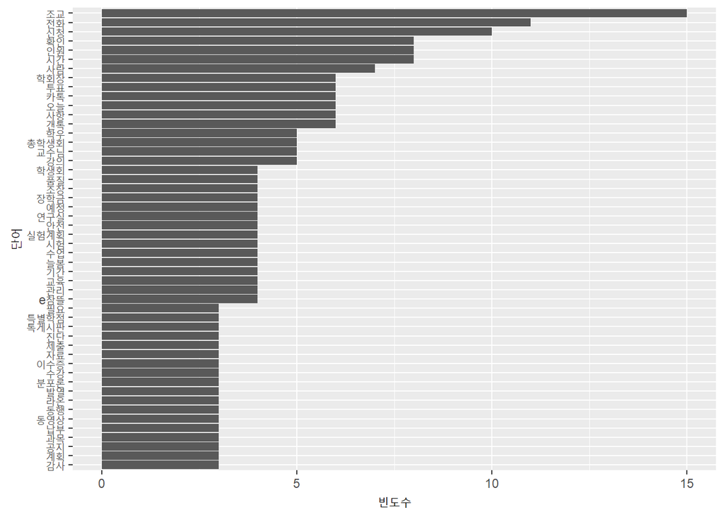

```r
#빈도수 막대 그래프로 확인하기
df <- as.data.frame(data_final)
df <- rename(df, word = data_list)

ggplot(data = df, aes(x = reorder(word, Freq), y = Freq)) +
  geom_col() +
  coord_flip() +
  xlab('단어') +
  ylab('빈도수')
```

#### 10. 워드 클라우드 생성

wordcloud2 함수를 이용해 최종적으로 워드 클라우드를 생성한다.  
size = 숫자: 크기 조정(숫자가 클수록 크기가 커짐)  
fontFamliy: 폰트 지정 함수

```r
set.seed(1234) # 난수 설정
pal <- brewer.pal(9, "Blues")[5:9]
wordcloud2(data_final, size = 0.7, fontFamily = "Tmon몬소리", color = pal)
```

[interactive chart not shown]

**[결과]**  
결과를 보면 ‘조교’라는 단어가 먼저 보인다. 그 다음으로는 ’전화’, ‘신청’, ‘인원’ 등이 많다. 학과 대화방은 개인 사담보다 공지사항이 주를 이룬다. 공지 사항은 조교선생님이 과대표에게 내용을 전달하고 그것을 대화방으로 알리는 방법으로 전해진다.

과대표가 전달하는 내용은 대부분이 **＂~~인 사람/하고 싶은 사람/에 신청할 인원은 조교님께 카톡이나 전화 주세요.＂**이다. 역으로 생각하면 워드 클라우드의 결과를 이해할 수 있다.

**[느낀 점]**  
이번 분석 과정을 R 마크다운 보고서로 작성하려 했는데, 마지막의 워드 클라우드를 실현 시키는 과정에서 오류가 발생했다. 페이스북의 ‘데이터 분석 커뮤니티’에 질문 글을 올렸다.  
답변 결과는 다음과 같다. wordcloud2 패키지에서는 기본적으로 결과물을 html로 만들기 때문에 docx로는 표현이 안 될 수 있다고 한다. 아쉽지만 word 문서 말고 html 파일로 작성했다.

본 프로젝트는 R 기초 교재를 끝낸 후(2021.01) 처음으로 혼자 한 프로젝트라서 어려웠던 기억이 있었다. 그래도 인터넷의 많은 자료를 참고해서 모방학습한 것이고 스스로 직접 찾아서 한 것 자체가 의미 있다고 생각한다.

5개월 만에 다시 해보는 작업인데 이전보다 코드에 대한 이해도와 모르는 것을 구글링하는 실력이 올라간 것 같아서 뿌듯했다.